# A Multination Study of Socioeconomic Inequality in Expectations for Progression to Higher Education: The Role of Between School Tracking and Ability Stratification

Philip D. Parker, John Jerrim, Ingrid Schoon, Herbert W. Marsh

28 September 2015

Self-archive version can be downloaded here

The supplementary material contains the formulars used to construct total, primary, and secondary effects as estimated in the paper. In addition, in keeping with growing calls for reproducible research (see Mesirov, 2010 *Accessible reproducible research*, Science, 327, 415-416) all analysis steps to obtain the final solutions presented in the paper and links to obtain the original data are presented. The paper below provides actual input code but also associated outputs. As the exact outputs are presented any warnings produced by R are maintained. These warnings were all investigated and found to not effect the results in any way. The warning are left in tact to provide a full record for researchers who wish to replicate the results.

## 0.1 Formula Used to Derive Primary and Secondary Effects in Current Research

The general formula is: $\begin{equation}y^{i} = \alpha +B y^{i} + \Gamma x^{i} + \zeta_{i}\end{equation}$

With matricies: $\begin{aligned}y_{i} = \begin{bmatrix} Expect\\ Ach \end{bmatrix}\end{aligned}$

$\begin{aligned}\alpha = \begin{bmatrix} \beta^{Expect}_{0}\\ \beta^{Ach}_{0} \end{bmatrix}\end{aligned}$

$\begin{aligned}B= \begin{bmatrix} 0 & \beta^{Ach}_{Expect}\\ 0&0 \end{bmatrix}\end{aligned}$

$\begin{aligned}\Gamma= \begin{bmatrix} \beta^{Expect}_{SES}\\ \beta^{Ach}_{SES} \end{bmatrix}\end{aligned}$

$\begin{aligned} \zeta = \begin{bmatrix} e^{Expect}_{i}\\ e^{Ach}_{i} \end{bmatrix} \sim N(o, \Psi ) \text{where} \Psi = \begin{bmatrix} \sigma^{2}_{ei:Expect} & 0\\ 0&\sigma^{2}_{ei:Ach} \end{bmatrix}\end{aligned}$

The effects of interest are then derived from the coefficents from this model as follows:

Secondary effects $=\beta^{Expect}_{SES}$

Primary effects $=\beta^{Ach}_{SES} \times \beta^{Expect}_{Ach}$

Total effects $=\beta^{Expect}_{SES} + (\beta^{Ach}_{SES} \times \beta^{Expect}_{Ach})$

and where:

Expect = the expectations of obtaining a university level of education

Ach = academic achievement as measured by PISA achievement tests

SES = socioeconomic status of the child

## 0.2 Data Preperation

University expectations variable is also created from the **SISCED** variable in the PISA database.

The R packages used in this paper are:

```r
library(RSQLite)
library(psych)
library(multilevel)
library(MplusAutomation)
library(ppcor)
library(weights)
library(knitr)
```

```r
HDI <- read.csv("~/Dropbox/Projects_Research/Social Forces/PISA2003/data/Table_1__Human_Development_Index_and_its_components.csv", na.strings = "..")
PISA <- dbConnect(SQLite(), dbname="~/Dropbox/Databases/LSAY_DATSETS/LSAY.sqlite")
#dbListTables(LSAY)
reducedData <- dbGetQuery(PISA, "SELECT CNT, SCHOOLID, AGE, GRADE, ST03Q01, HISEI, HISCED,ESCS,
                           IMMIG, OECD, SISCED, W_FSTUWT,
                          PV1MATH,PV2MATH,PV3MATH,PV4MATH,PV5MATH,
                          PV1READ,PV2READ,PV3READ,PV4READ,PV5READ,
                          PV1SCIE,PV2SCIE,PV3SCIE,PV4SCIE,PV5SCIE FROM PISA2003")
#summary(reducedData)
reducedData<- reducedData[reducedData$OECD==1,]
#Remove non-OECD from levels
reducedData$CNT<-factor(reducedData$CNT)
#Add university expectation binary variable
reducedData$UNI <- ifelse(reducedData$SISCED==5, 1, ifelse(reducedData$SISCED==9, NA, 0))
#For pooled standadization z-score HISEI and HISCED
reducedData[,6:7]<- scale(reducedData[,6:7])
```

To manage memory the smaller analysis dataset is saved and then the workspace is cleared. The smaller data set is then sourced for the remaining analysis.

### 0.2.1 Creation of Principal Components

Principals components of PISA math, verbal, and science tests were constructed as follows:

```r
#Z-score achievement
reducedData[,grep("^PV[0-9]", names(reducedData))]<- scale(reducedData[,grep("^PV[0-9]",
                                                                        names(reducedData))]
                                                           )
#Principal Value analaysis
#Achievement scores
Ach <- list()
for ( i in 1:5){
                Ach[[i]]<-principal(reducedData[,grep(paste0("^PV", i, ".*$"),
                                                      names(reducedData))], 1, score=TRUE)$scores
                }
Ach<- do.call(cbind.data.frame, Ach)
names(Ach)<-paste0("Ach", 1:5)
#add principal components to dataframe
AchData <- data.frame(reducedData, Ach)
```

### 0.2.2 Construction of Intraclass correlations (ICC)

```r
#ICCs
# load("C:/Users/30016475/Dropbox/Projects_Research/Social Forces/PISA2003/data/AchData19013013.RData")
ICCdata<- split(AchData, AchData$CNT)
ICC<-list()
for (i in 1:5) {
x<- lapply(ICCdata, function(x) ICC1(aov(x[,i+27]~as.factor(SCHOOLID), data=x, weights=W_FSTUWT)))
ICC[[i]]<- data.frame(do.call(rbind, x))
}

ICCs<-do.call(cbind,ICC)
ICCs<- apply(ICCs, 1, mean)
ICCs<- data.frame(ICCs=matrix(as.numeric(ICCs), nrow=30), CNT=names(ICCs))
names(ICCs)<-c("ICC", "CNT")

#Aggregate the ICCs back into the data set
AchData <- merge(AchData, ICCs, by="CNT")
```

## 0.3 Descriptive Results

Descriptive results consist of: * n.obs = Number of observations * selection = Age of first selection * Exptect.tables = Proportion of students expecting a university level of education or greater * ICCs = Intraclass correlations for between school academic ability stratification * avg.ach = Average achievement for each country on the principal components of the PISA academic ability tests.

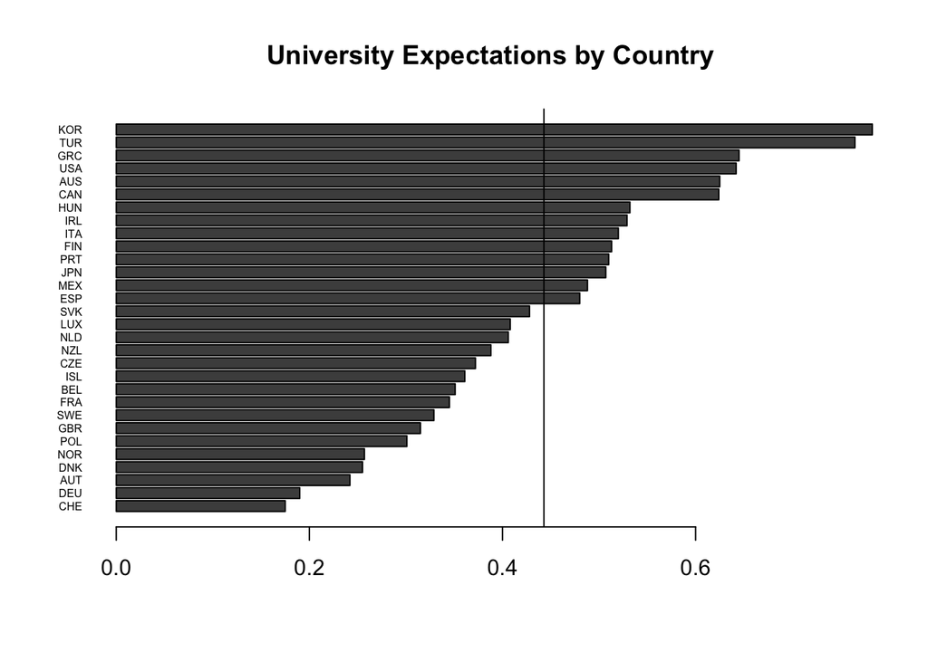

```r
# Human development index
HDI <- read.csv("~/Dropbox/Projects_Research/Social Forces/PISA2003/data/Table_1__Human_Development_Index_and_its_components.csv",
    na.strings = "..")
w.means <- split(AchData[, c("UNI", "CNT", "W_FSTUWT")], as.factor(AchData$CNT))
w.expect <- sapply(w.means, function(x) weighted.mean(x$UNI, x$W_FSTUWT, na.rm=TRUE) )
#Age of first selection
descriptives<-data.frame(n.obs=tapply(AchData$CNT, AchData$CNT, length),
                         strat = c(-1.043, 1.817, 1.018, -1.321, -0.138, 1.621, 1.862,
    -0.087, -1.02, -0.87, -0.474, -1.043, -0.474, 1.421, -0.302, -0.063, 0.166,
    -0.474, 0.072, 0.7, NA, 0.937, -1.043, -0.419, -0.083, -0.327, 1.621, -0.138,
    1.201, -1.321),
                         ICC=round(tapply(AchData$ICC, AchData$CNT, mean),3),
                         Expect.tables=round(w.expect,3),
                        avg.ach= round(tapply(AchData$Ach1, AchData$CNT, mean),3)
                         )
descriptives$CNT <- row.names(descriptives)
descriptives$HDI <- HDI[HDI$Abbreviation %in% descriptives$CNT, 5]
descriptives2 <- data.frame(descriptives[order(descriptives$Expect.tables), ])
DESplot <- as.table(t(descriptives2[, c("Expect.tables", "CNT")]))
barplot(DESplot, horiz = TRUE, cex.names = 0.5, las = 1, main = "University Expectations by Country")
abline(v = mean(descriptives$Expect.tables, na.rm = TRUE))
```

```r
round(cor(descriptives[, c(2:5, 7)], use = "pairwise.complete.obs"),3)
```

```
##                strat    ICC Expect.tables avg.ach    HDI
## strat          1.000  0.687        -0.235  -0.130 -0.374
## ICC            0.687  1.000         0.098  -0.179 -0.355
## Expect.tables -0.235  0.098         1.000  -0.165 -0.289
## avg.ach       -0.130 -0.179        -0.165   1.000  0.726
## HDI           -0.374 -0.355        -0.289   0.726  1.000
```

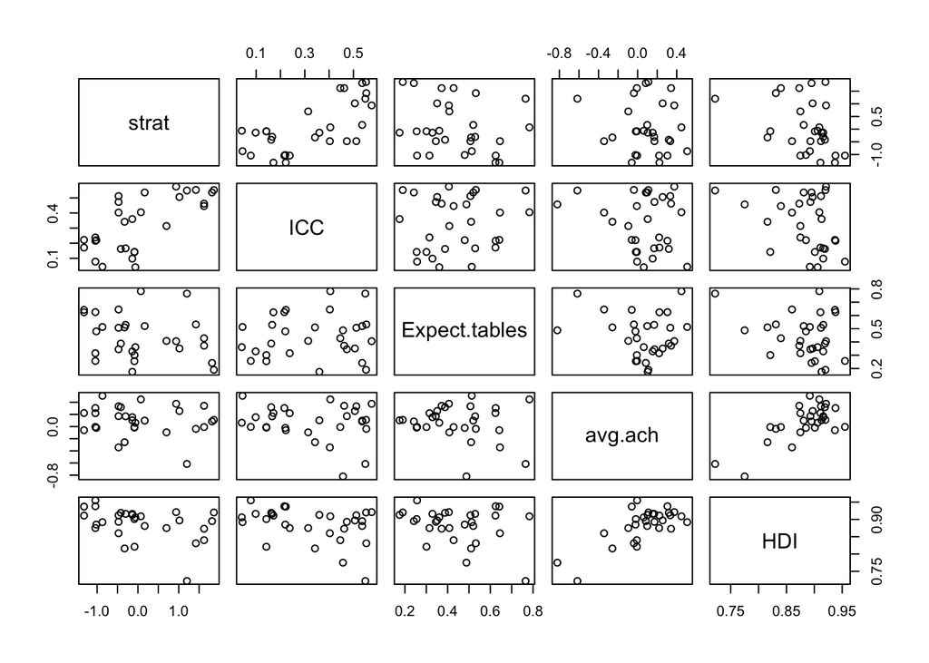

```r
pairs(descriptives[, c(2:5, 7)])
```

### Descriptive Results

|  | n.obs | strat | ICC | Expect.tables | avg.ach | CNT | HDI |
| --- | --- | --- | --- | --- | --- | --- | --- |
| CHE | 8420 | -0.138 | 0.360 | 0.175 | 0.103 | CHE | 0.913 |
| DEU | 4660 | 1.862 | 0.552 | 0.190 | 0.110 | DEU | 0.920 |
| AUT | 4597 | 1.817 | 0.536 | 0.242 | 0.084 | AUT | 0.895 |
| DNK | 4218 | -0.087 | 0.142 | 0.255 | -0.018 | DNK | 0.901 |
| NOR | 4064 | -1.043 | 0.078 | 0.257 | -0.005 | NOR | 0.955 |
| POL | 4383 | -0.083 | 0.142 | 0.301 | -0.008 | POL | 0.821 |
| GBR | 9535 | -1.043 | 0.238 | 0.315 | 0.220 | GBR | 0.875 |
| SWE | 4624 | -0.138 | 0.098 | 0.329 | 0.154 | SWE | 0.916 |
| FRA | 4300 | -0.474 | 0.473 | 0.345 | 0.172 | FRA | 0.893 |
| BEL | 8796 | 1.018 | 0.506 | 0.351 | 0.256 | BEL | 0.897 |
| ISL | 3350 | -0.063 | 0.041 | 0.361 | 0.063 | ISL | 0.906 |
| CZE | 6320 | 1.621 | 0.462 | 0.372 | 0.342 | CZE | 0.873 |
| NZL | 4511 | -0.419 | 0.162 | 0.388 | 0.319 | NZL | 0.919 |
| NLD | 3992 | 0.937 | 0.575 | 0.406 | 0.375 | NLD | 0.921 |
| LUX | 3923 | 0.700 | 0.314 | 0.408 | -0.095 | LUX | 0.875 |
| SVK | 7346 | 1.621 | 0.446 | 0.428 | -0.008 | SVK | 0.840 |
| ESP | 10791 | -1.020 | 0.220 | 0.480 | -0.022 | ESP | 0.885 |
| MEX | 29983 | NA | 0.457 | 0.488 | -0.821 | MEX | 0.775 |
| JPN | 4707 | -0.474 | 0.512 | 0.507 | 0.334 | JPN | 0.912 |
| PRT | 4608 | -0.327 | 0.342 | 0.510 | -0.258 | PRT | 0.816 |
| FIN | 5796 | -0.870 | 0.044 | 0.513 | 0.507 | FIN | 0.892 |
| ITA | 11639 | 0.166 | 0.536 | 0.520 | 0.098 | ITA | 0.881 |
| IRL | 3880 | -0.302 | 0.166 | 0.529 | 0.169 | IRL | 0.916 |
| HUN | 4765 | 1.421 | 0.553 | 0.532 | -0.038 | HUN | 0.831 |
| CAN | 27953 | -1.321 | 0.171 | 0.624 | 0.223 | CAN | 0.911 |
| AUS | 12551 | -1.043 | 0.216 | 0.625 | 0.305 | AUS | 0.938 |
| USA | 5456 | -1.321 | 0.222 | 0.642 | -0.060 | USA | 0.937 |
| GRC | 4627 | -0.474 | 0.403 | 0.645 | -0.343 | GRC | 0.860 |
| TUR | 4855 | 1.201 | 0.549 | 0.765 | -0.616 | TUR | 0.722 |
| KOR | 5444 | 0.072 | 0.405 | 0.783 | 0.448 | KOR | 0.909 |

## 0.4 Mplus Probit Models

First the R data file is saved for use in Mplus using the MplusAutomation package. Five data sets are created each with one plausable value for the Achievement principal component.

```
#{r mplusData}
library(MplusAutomation)
for (i in 1:5){
  capture.output(prepareMplusData(AchData[,c(1:28,34,28+i)],
                   filename=paste0("~/Dropbox/Projects_Research/Social Forces/AERJ/PISA2003_PV", i, ".dat")
                 ))
}
```

All models are run using a single Mplus template file. The template file is:

```
TITLE: Country XXX !Outcome = Expectation of university entry
                    !Treatment mediator Interaction;
DATA: FILE = "PISA2003_PV1.dat";
!type=imputation;

VARIABLE:
NAMES = CNT SCHOOLID AGE GRADE ST03Q01 HISEI HISCED ESCS IMMIG OECD SISCED W_FSTUWT
     PV1MATH PV2MATH PV3MATH PV4MATH PV5MATH PV1READ PV2READ PV3READ PV4READ PV5READ
     PV1SCIE PV2SCIE PV3SCIE PV4SCIE PV5SCIE UNI ICC PVAch;
MISSING=.;

USEVARIABLES UNI HISEI PVAch int;
categorical = UNI;
useobs CNT EQ 1;
cluster=schoolid;
weight=W_FSTUWT;

DEFINE: int = HISEI*PVAch;

analysis: type=complex; estimator = MLR; LINK = PROBIT;
DEFINE: STANDARDIZE HISEI PVAch int;

MODEL:
[UNI$1] (mbeta0);
UNI on HISEI (beta2);
UNI on PVAch (beta1);
UNI on int (beta3);
[PVAch](gamma0);
PVAch on HISEI (gamma1);
PVAch(sig2);

MODEL CONSTRAINT:
new(ind dir arg11 arg10 arg01 arg00 v1 v0
    probit11 probit10 probit01 probit00
    tie de pie ortie orde orpie Ctotal total prop);

    dir=beta3*gamma0+beta2;
    ind=beta1*gamma1+beta3*gamma1;
    arg11=-mbeta0+beta2+(beta1+beta3)*(gamma0+gamma1);
    arg10=-mbeta0+beta2+(beta1+beta3)*gamma0;
    arg01=-mbeta0+beta1*(gamma0+gamma1);
    arg00=-mbeta0+beta1*gamma0;
    v1=(beta1+beta3)^2*sig2+1;
    v0=beta1^2*sig2+1;
    probit11=arg11/sqrt(v1);
    probit10=arg10/sqrt(v1);
    probit01=arg01/sqrt(v0);
    probit00=arg00/sqrt(v0);
    ! Phi function needed below:
    tie=phi(probit11)-phi(probit10);
    de=phi(probit10)-phi(probit00);
    pie=phi(probit01)-phi(probit00);
    ortie=(phi(probit11)/(1-phi(probit11)))/
    (phi(probit10)/(1-phi(probit10)));
    orde=(phi(probit10)/(1-phi(probit10)))/
    (phi(probit00)/(1-phi(probit00)));
    orpie=(phi(probit01)/(1-phi(probit01)))/
    (phi(probit00)/(1-phi(probit00)));
    Ctotal = de + tie;
    total= ind + dir;
    prop = (tie)/ (Ctotal+.00001);
```

The template file is iterative over in order to create country specific syntax files. The creation and running of files is done via the following user defined function. Before creating these files relavent directories are created in the working directory; one each for every ses.var used.

```
{r fileCreation, warning=FALSE, message=FALSE}
fileCreation <- function(ses.var = "HISEI", link = "PROBIT") {
    temp <- readLines("~/Dropbox/Projects_Research/Social Forces/AERJ/TEMPLATEFILE19012013.inp")
    temp[10:60] <- unlist(sapply(temp[10:60], function(x) gsub("HISEI", ses.var,
        x)))
    countries <- levels(AchData$CNT)
    if (link == "LOGIT") {
        link = "LOGIT"
        temp <- gsub("PROBIT", "LOGIT", temp)
    } else {
        link = "PROBIT"
    }
    print(link)
    print(ses.var)
    for (i in 1:30) {
        x <- temp
        x[1] <- gsub("XXX", countries[i], x[1])
        x[13] <- paste0("useobs CNT EQ ", i, ";")
        cat(x, sep = "\n", file = paste0("~/Dropbox/Projects_Research/Social Forces/AERJ/",
            ses.var, "/", link, "/", countries[i], ".inp"))
    }
}
fileCreation(ses.var = "HISEI", link = "LOGIT")  # Highest occupation prestige of parents
fileCreation(ses.var="HISCED", link = "LOGIT")# Highest education level of parents
fileCreation(ses.var="ESCS", link = "LOGIT")# Highest education level of parents

fileCreation(ses.var = "HISEI", link = "PROBIT")  # Highest occupation prestige of parents
fileCreation(ses.var="HISCED", link = "PROBIT")# Highest education level of parents
fileCreation(ses.var="ESCS", link = "PROBIT")# Highest education level of parents
```

All the models in each of the folders are run using MplusAutomation package in R

```
runModels("~/Dropbox/Projects_Research/Social Forces/AERJ", recursive=TRUE)
```

## 0.5 Parameter Extraction and Presentation

Extraction of results for presentaton and further analysis was done using the following user defined functions.

```r
#Run on mplus files one at a time
paths <- list.dirs("~/Dropbox/Projects_Research/Social Forces/AERJ/", full.names = TRUE, recursive = TRUE)
paths <- grep("(ESCS|HISEI|HISCED)/(LOGIT|PROBIT)", paths, value=TRUE)

parameterExtract<- function(path){
      files <- list.files(path,  full.names = TRUE)
      files <- grep(".out$", files, value=TRUE)
      #Extract relavent output
      temp<-grep("New/Additional Parameters", readLines(files[1]))
      lines<-temp+c(13, 14,19,21)
      output <- sapply(files, function(x) readLines(x)[lines])
      #Function for extracting relavent parameters
      f1<-function(x) unlist(strsplit(x,"[[:space:]]+"))[c(2:4)]
      results<-apply(output, c(1,2), f1)
      TIE<- matrix(results[,1,1:30],30, 3, byrow = TRUE)
      DE<- matrix(results[,2,1:30],30, 3, byrow = TRUE)
      total<- matrix(results[,3,1:30],30, 3, byrow = TRUE)
      prop<- matrix(results[,4,1:30],30, 3, byrow = TRUE)
      results<- cbind(total, TIE, DE, prop)
      results<-data.frame(results[,c(2:3,5:6,8:9, 11:12)],
                          descriptives2[order(descriptives2$CNT),c(2:3, 5,7)])
      names(results)<-c("total", "totalse", "ind", "indse", "dir", "dirse", "prop",
                        "propse","strat", "ICC", "avg.ability", "HDI")
      results<- data.frame(apply(results, 2, as.numeric))
      results$CNT<-levels(AchData$CNT)
      results
}

resultsList <-lapply(paths, parameterExtract)
names(resultsList)<- gsub("(/Users/phparker/Dropbox/Projects_Research/Social Forces/AERJ/)/(.*)/(.*)$",
                          "\\2 \\3", paths)

#Run on mplus files one at a time
paths <- list.dirs("~/Dropbox/Projects_Research/Social Forces/AERJ/", full.names = TRUE, recursive = TRUE)
paths <- grep("(ESCS|HISEI|HISCED)/LPM", paths, value=TRUE)

parameterExtract<- function(path){
      files <- list.files(path,  full.names = TRUE)
      files <- grep(".out$", files, value=TRUE)
      #Extract relavent output
      temp<-grep("New/Additional Parameters", readLines(files[1]))
      lines<-temp[1]+c(1:4)
      output <- sapply(files, function(x) readLines(x)[lines])
      #Function for extracting relavent parameters
      f1<-function(x) unlist(strsplit(x,"[[:space:]]+"))[c(2:4)]
      results<-apply(output, c(1,2), f1)
      IND <- matrix(results[,1,1:30],30, 3, byrow = TRUE)
      DIR<- matrix(results[,2,1:30],30, 3, byrow = TRUE)
      total<- matrix(results[,3,1:30],30, 3, byrow = TRUE)
      prop<- matrix(results[,4,1:30],30, 3, byrow = TRUE)
      results<- cbind(total, IND, DIR, prop)
      results<-data.frame(results[,c(2:3,5:6,8:9, 11:12)],
                          descriptives2[order(descriptives2$CNT),c(2:3, 5,7)])
      names(results)<-c("total", "totalse", "ind", "indse", "dir", "dirse", "prop",
                        "propse","strat", "ICC", "avg.ability", "HDI")
      results<- data.frame(apply(results, 2, as.numeric))
      results$CNT<-levels(AchData$CNT)
      results
}

resultsListb <-lapply(paths, parameterExtract)
names(resultsListb)<- gsub("(/Users/phparker/Dropbox/Projects_Research/Social Forces/AERJ/)/(.*)/(.*)$",
                          "\\2 \\3", paths)
resultsList <- c(resultsList, resultsListb)
resultsList2 <- lapply(resultsList, na.omit)
```

## 0.6 Plots and Correlations between Model Results and Country ICCs

```r
inverseVar <- function(mu, omega){
  d = sum(mu/omega)
  n = sum(1/omega)
  y = d/n
  y
}

inv.weight <- function(se) {
  u.weight = 1/se
  u.weight.tot = sum(u.weight)
  a.factor = solve(u.weight.tot, length(se))
  u.weight*a.factor
}

w.pcor <- function(y,x, cov, weight){
  x.res = lm(x ~ ., data = data.frame(x,cov), weight = weight)$residuals
  y.res = lm(y ~ ., data = data.frame(y,cov), weight = weight)$residuals
  p.cor = wtd.cor(x.res, y.res, weight = weight)
  p.cor
}

#---------
#Average Effect Size
sapply(resultsList, function(x) inverseVar(x$total, x$totalse))
```

```
##    ESCS LOGIT   ESCS PROBIT  HISCED LOGIT HISCED PROBIT   HISEI LOGIT
##     0.2279349     0.1878100     0.1773621     0.1438383     0.1701240
##  HISEI PROBIT      ESCS LPM    HISCED LPM     HISEI LPM
##     0.1361035     0.1790321     0.1420209     0.1320916
```

```r
sapply(resultsList, function(x) inverseVar(x$prop, x$propse))
```

```
##    ESCS LOGIT   ESCS PROBIT  HISCED LOGIT HISCED PROBIT   HISEI LOGIT
##     0.3886083     0.3929702     0.3663744     0.3723757     0.4576961
##  HISEI PROBIT      ESCS LPM    HISCED LPM     HISEI LPM
##     0.4553049     0.4090565     0.3824775     0.4642482
```

```r
#--------------------------
#H1: Effect of tracking on total effect
#Unweighted
h1.uwa <- sapply(resultsList, function(x) wtd.cor(x$total, x$strat, weight = NULL) )[1,]
h1.uwb <- sapply(resultsList2, function(x) w.pcor(x$total, x$strat, cov = x[, c("ICC", "HDI", "avg.ability")],
       weight = NULL )
       )[1,]
#Weighted
h1.wa <- sapply(resultsList, function(x) wtd.cor(x$total, x$strat, weight = inv.weight(x$totalse)) )[1,]
h1.wb <- sapply(resultsList2, function(x) w.pcor(x$total, x$strat, cov = x[, c("ICC", "HDI", "avg.ability")],
       weight = inv.weight(x$totalse) )
       )[1,]
#--------------------------
#H2: Effect of Stratification on total effect
#unweighted
h2.uwa <- sapply(resultsList, function(x) wtd.cor(x$total, x$ICC, weight = NULL) )[1,]
h2.uwb <- sapply(resultsList2, function(x) w.pcor(x$total, x$ICC, cov = x[, c("strat", "HDI", "avg.ability")],
       weight = NULL )
       )[1,]
#weighted
h2.wa <- sapply(resultsList, function(x) wtd.cor(x$total, x$ICC, weight = inv.weight(x$totalse)) )[1,]
h2.wb <- sapply(resultsList2, function(x) w.pcor(x$total, x$ICC, cov = x[, c("strat", "HDI", "avg.ability")],
       weight = inv.weight(x$totalse) )
       )[1,]
#--------------------------
#H3: Effect of tracking on primary effect
#unweighted
h3.uwa <- sapply(resultsList, function(x) wtd.cor(x$prop, x$strat, weight = NULL) )[1,]
h3.uwb <- sapply(resultsList2, function(x) w.pcor(x$prop, x$strat, cov = x[, c("ICC", "HDI", "avg.ability")],
       weight = NULL)
       )[1,]
#weighted
h3.wa <- sapply(resultsList, function(x) wtd.cor(x$prop, x$strat, weight = inv.weight(x$propse)) )[1,]
h3.wb <- sapply(resultsList2, function(x) w.pcor(x$prop, x$strat, cov = x[, c("ICC", "HDI", "avg.ability")],
       weight = inv.weight(x$propse) )
       )[1,]
#--------------------------
#H4: Effect of Stratification on primary effect
#unweighted
h4.uwa <- sapply(resultsList, function(x) wtd.cor(x$prop, x$ICC, weight = NULL) )[1,]
h4.uwb <- sapply(resultsList2, function(x) w.pcor(x$prop, x$ICC, cov = x[, c("strat", "HDI", "avg.ability")],
       weight = NULL )
       )[1,]
#weighted
h4.wa <- sapply(resultsList, function(x) wtd.cor(x$prop, x$ICC, weight = inv.weight(x$propse)) )[1,]
h4.wb <- sapply(resultsList2, function(x) w.pcor(x$prop, x$ICC, cov = x[, c("strat", "HDI", "avg.ability")],
       weight = inv.weight(x$propse) )
       )[1,]
#--------------------------
```

### Results: Unweighted and Unadjusted

|  | ESCS LOGIT | ESCS PROBIT | HISCED LOGIT | HISCED PROBIT | HISEI LOGIT | HISEI PROBIT | ESCS LPM | HISCED LPM | HISEI LPM |
| --- | --- | --- | --- | --- | --- | --- | --- | --- | --- |
| Hypothesis 1 | 0.375 | 0.483 | 0.315 | 0.471 | 0.416 | 0.498 | 0.273 | 0.279 | 0.384 |
| Hypothesis 2 | 0.209 | 0.408 | 0.033 | 0.256 | 0.299 | 0.427 | 0.275 | 0.173 | 0.337 |
| Hypothesis 3 | 0.437 | 0.423 | 0.565 | 0.545 | 0.289 | 0.298 | 0.422 | 0.559 | 0.368 |
| Hypothesis 4 | 0.424 | 0.472 | 0.621 | 0.621 | 0.357 | 0.405 | 0.428 | 0.601 | 0.435 |

### Results: Unweighted and Adjusted

|  | ESCS LOGIT | ESCS PROBIT | HISCED LOGIT | HISCED PROBIT | HISEI LOGIT | HISEI PROBIT | ESCS LPM | HISCED LPM | HISEI LPM |
| --- | --- | --- | --- | --- | --- | --- | --- | --- | --- |
| Hypothesis 1 | 0.340 | 0.308 | 0.414 | 0.417 | 0.294 | 0.293 | 0.168 | 0.269 | 0.229 |
| Hypothesis 2 | -0.082 | 0.117 | -0.290 | -0.125 | -0.006 | 0.119 | 0.152 | -0.028 | 0.117 |
| Hypothesis 3 | 0.192 | 0.128 | 0.148 | 0.113 | 0.042 | 0.002 | 0.184 | 0.154 | 0.055 |
| Hypothesis 4 | 0.220 | 0.307 | 0.409 | 0.424 | 0.265 | 0.319 | 0.249 | 0.398 | 0.289 |

### Results: Weighted and Unadjusted

|  | ESCS LOGIT | ESCS PROBIT | HISCED LOGIT | HISCED PROBIT | HISEI LOGIT | HISEI PROBIT | ESCS LPM | HISCED LPM | HISEI LPM |
| --- | --- | --- | --- | --- | --- | --- | --- | --- | --- |
| Hypothesis 1 | 0.237 | 0.475 | 0.205 | 0.480 | 0.334 | 0.507 | 0.264 | 0.305 | 0.337 |
| Hypothesis 2 | 0.059 | 0.381 | -0.044 | 0.271 | 0.210 | 0.433 | 0.255 | 0.194 | 0.288 |
| Hypothesis 3 | 0.454 | 0.453 | 0.576 | 0.569 | 0.303 | 0.301 | 0.471 | 0.580 | 0.350 |
| Hypothesis 4 | 0.382 | 0.440 | 0.615 | 0.617 | 0.283 | 0.318 | 0.419 | 0.581 | 0.330 |

### Results: Weighted and Adjusted

|  | ESCS LOGIT | ESCS PROBIT | HISCED LOGIT | HISCED PROBIT | HISEI LOGIT | HISEI PROBIT | ESCS LPM | HISCED LPM | HISEI LPM |
| --- | --- | --- | --- | --- | --- | --- | --- | --- | --- |
| Hypothesis 1 | 0.349 | 0.327 | 0.412 | 0.434 | 0.300 | 0.298 | 0.191 | 0.285 | 0.222 |
| Hypothesis 2 | -0.150 | 0.071 | -0.276 | -0.131 | -0.036 | 0.111 | 0.139 | -0.020 | 0.102 |
| Hypothesis 3 | 0.264 | 0.206 | 0.163 | 0.133 | 0.137 | 0.095 | 0.259 | 0.210 | 0.162 |
| Hypothesis 4 | 0.140 | 0.227 | 0.388 | 0.389 | 0.148 | 0.192 | 0.175 | 0.343 | 0.162 |

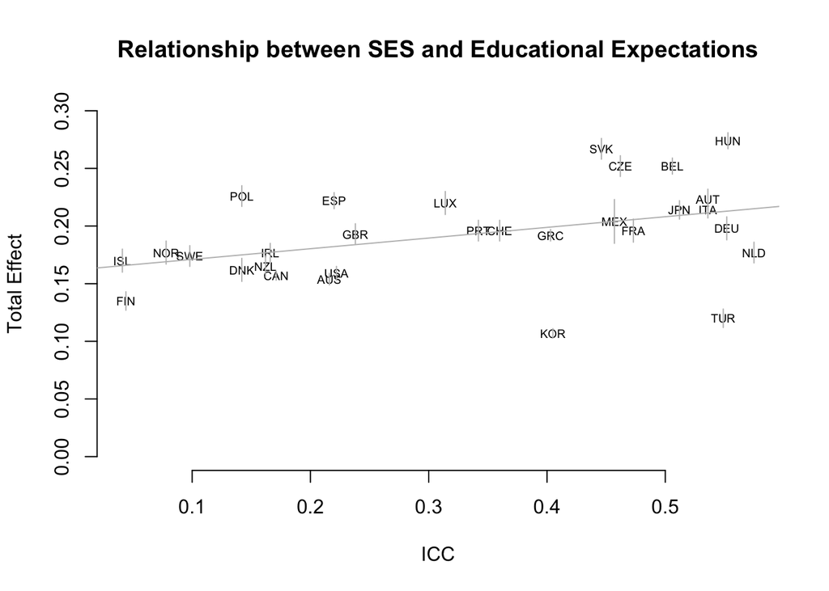

```r
#Plots for weights with country specific standadization
# library(RSvgDevice)
# devSVG("revisionToAERJ/R3/ICC_total.svg")
results<-resultsList[[2]]
plot(results[,"ICC"], results[,"total"], ylab="Total Effect", xlab="ICC", ylim=c(0,.3),pch = '', main="Relationship between SES and Educational Expectations", bty = "n")
text(results[,"ICC"],results[,"total"],results[,"CNT"], cex=.6)
abline(lm(results[,"total"]~results[,"ICC"]), col="grey")
arrows(x0 = results[,"ICC"], y0 = results[,"total"]-results[,"totalse"],
       x1 = results[,"ICC"], y1 = results[,"total"]+results[,"totalse"], length=0, col="grey")
```

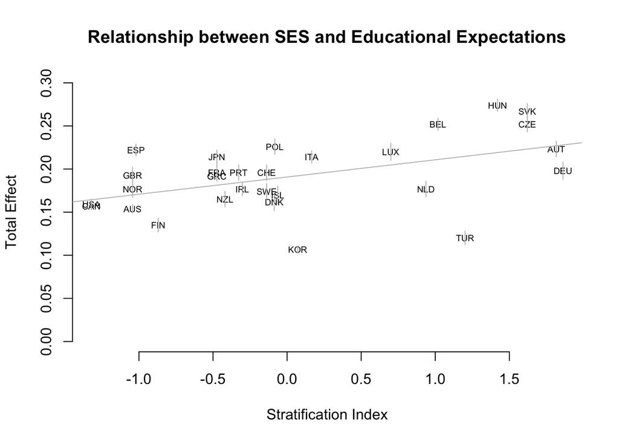

```r
# dev.off()
# devSVG("revisionToAERJ/R3/strat_total.svg")
plot(results[,"strat"], results[,"total"], ylab="Total Effect", xlab="Stratification Index", ylim=c(0,.3),pch = '', main="Relationship between SES and Educational Expectations", bty = "n")
text(results[,"strat"],results[,"total"],results[,"CNT"], cex=.6)
abline(lm(results[,"total"]~results[,"strat"]), col="grey")
arrows(x0 = results[,"strat"], y0 = results[,"total"]-results[,"totalse"],
       x1 = results[,"strat"], y1 = results[,"total"]+results[,"totalse"], length=0, col="grey")
```

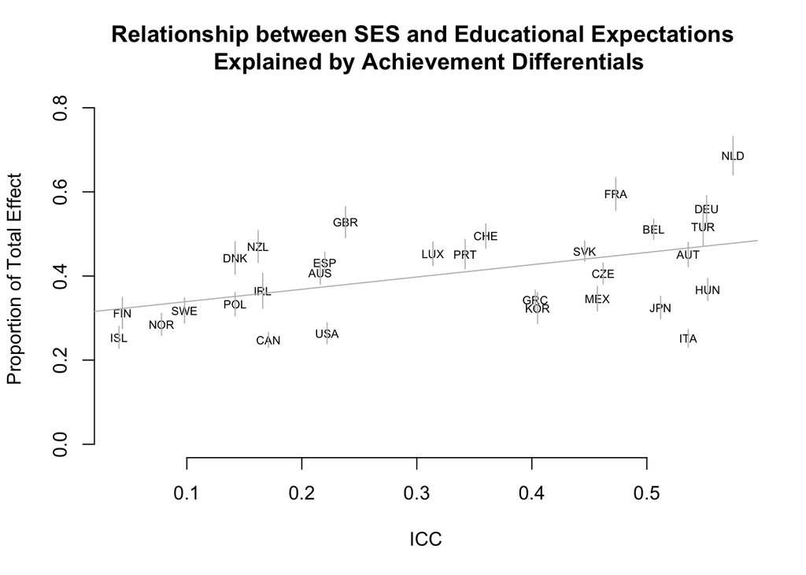

```r
# dev.off()
#Indirect Effect
# devSVG("revisionToAERJ/R3/ICC_ind.svg")
plot(results[,"ICC"], results[,"prop"], ylab="Proportion of Total Effect ", xlab="ICC", ylim=c(0,.8), pch = '',
     main="Relationship between SES and Educational Expectations \n Explained by Achievement Differentials", bty = "n")
text(results[,"ICC"],results[,"prop"],results[,"CNT"], cex=.6)
abline(lm(results[,"prop"]~results[,"ICC"]), col="grey")
arrows(x0 = results[,"ICC"], y0 = results[,"prop"]-results[,"propse"],
       x1 = results[,"ICC"], y1 = results[,"prop"]+results[,"propse"], length=0, col="grey")
```

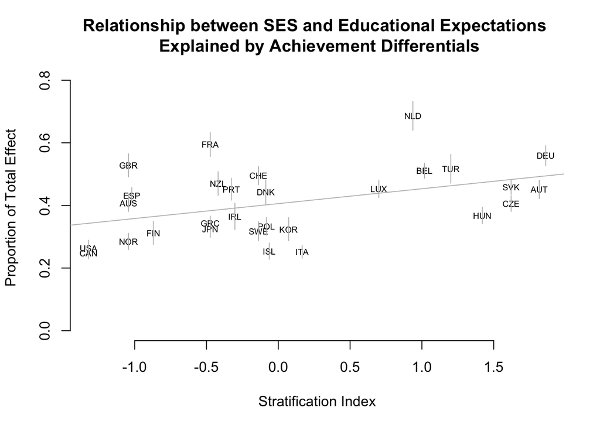

```r
# dev.off()
# devSVG("revisionToAERJ/R3/strat_ind.svg")
plot(results[,"strat"], results[,"prop"], ylab="Proportion of Total Effect ", xlab="Stratification Index", ylim=c(0,.8), pch = '', bty = "n",
     main="Relationship between SES and Educational Expectations \n Explained by Achievement Differentials")
text(results[,"strat"],results[,"prop"],results[,"CNT"], cex=.6)
abline(lm(results[,"prop"]~results[,"strat"]), col="grey")
arrows(x0 = results[,"strat"], y0 = results[,"prop"]-results[,"propse"],
       x1 = results[,"strat"], y1 = results[,"prop"]+results[,"propse"], length=0, col="grey")
```

```r
# dev.off()
```

## 0.7 Plots with highest parent education rather than highest parent occupational prestige

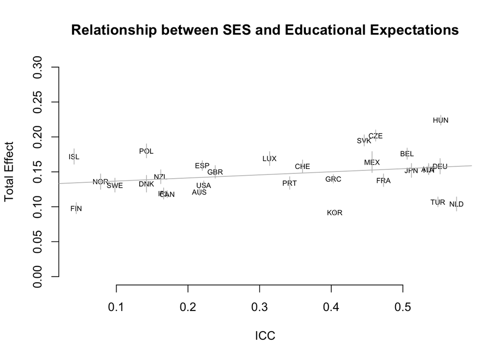

```r
results<-resultsList[[4]]
plot(results[,"ICC"], results[,"total"], ylab="Total Effect", xlab="ICC", ylim=c(0,.3),pch = '', main="Relationship between SES and Educational Expectations", bty = "n")
text(results[,"ICC"],results[,"total"],results[,"CNT"], cex=.6)
abline(lm(results[,"total"]~results[,"ICC"]), col="grey")
arrows(x0 = results[,"ICC"], y0 = results[,"total"]-results[,"totalse"],
       x1 = results[,"ICC"], y1 = results[,"total"]+results[,"totalse"], length=0, col="grey")
```

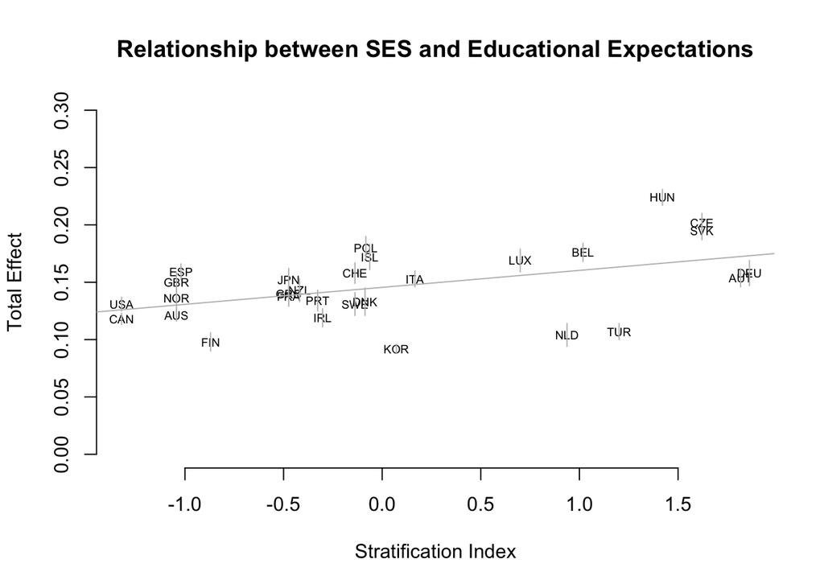

```r
# dev.off()
# devSVG("revisionToAERJ/R3/strat_total.svg")
plot(results[,"strat"], results[,"total"], ylab="Total Effect", xlab="Stratification Index", ylim=c(0,.3),pch = '', main="Relationship between SES and Educational Expectations", bty = "n")
text(results[,"strat"],results[,"total"],results[,"CNT"], cex=.6)
abline(lm(results[,"total"]~results[,"strat"]), col="grey")
arrows(x0 = results[,"strat"], y0 = results[,"total"]-results[,"totalse"],
       x1 = results[,"strat"], y1 = results[,"total"]+results[,"totalse"], length=0, col="grey")
```

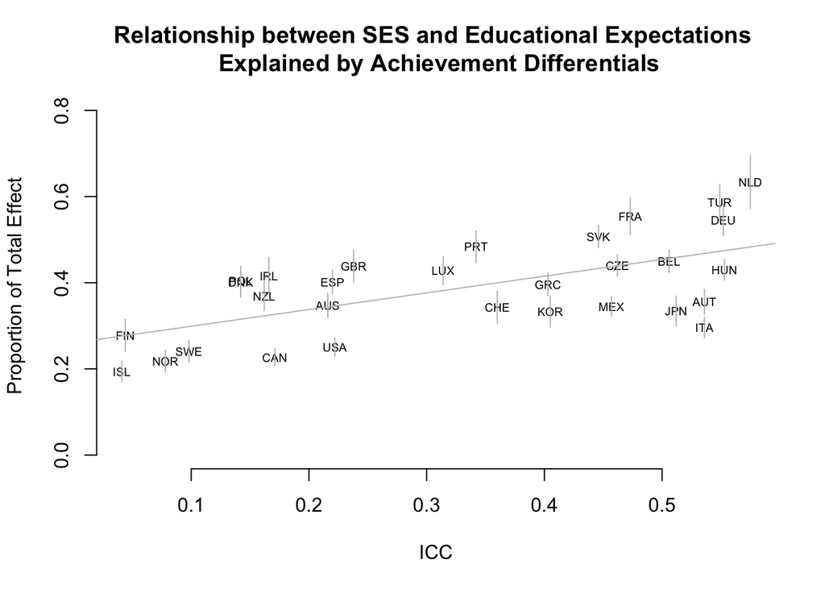

```r
# dev.off()
#Indirect Effect
# devSVG("revisionToAERJ/R3/ICC_ind.svg")
plot(results[,"ICC"], results[,"prop"], ylab="Proportion of Total Effect ", xlab="ICC", ylim=c(0,.8), pch = '',
     main="Relationship between SES and Educational Expectations \n Explained by Achievement Differentials", bty = "n")
text(results[,"ICC"],results[,"prop"],results[,"CNT"], cex=.6)
abline(lm(results[,"prop"]~results[,"ICC"]), col="grey")
arrows(x0 = results[,"ICC"], y0 = results[,"prop"]-results[,"propse"],
       x1 = results[,"ICC"], y1 = results[,"prop"]+results[,"propse"], length=0, col="grey")
```

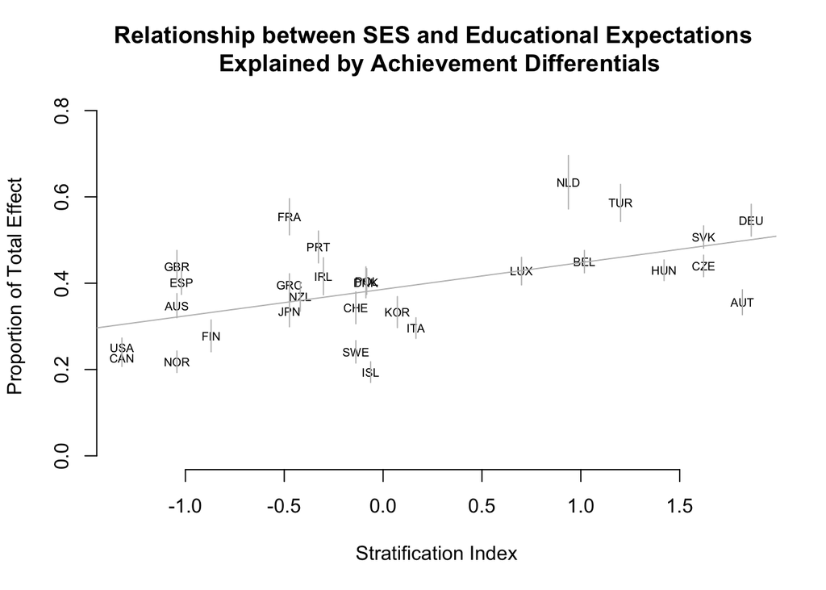

```r
# dev.off()
# devSVG("revisionToAERJ/R3/strat_ind.svg")
plot(results[,"strat"], results[,"prop"], ylab="Proportion of Total Effect ", xlab="Stratification Index", ylim=c(0,.8), pch = '', bty = "n",
     main="Relationship between SES and Educational Expectations \n Explained by Achievement Differentials")
text(results[,"strat"],results[,"prop"],results[,"CNT"], cex=.6)
abline(lm(results[,"prop"]~results[,"strat"]), col="grey")
arrows(x0 = results[,"strat"], y0 = results[,"prop"]-results[,"propse"],
       x1 = results[,"strat"], y1 = results[,"prop"]+results[,"propse"], length=0, col="grey")
```

```r
# dev.off()
```

## 0.8 Plots with PISA Highest Parental Occupation

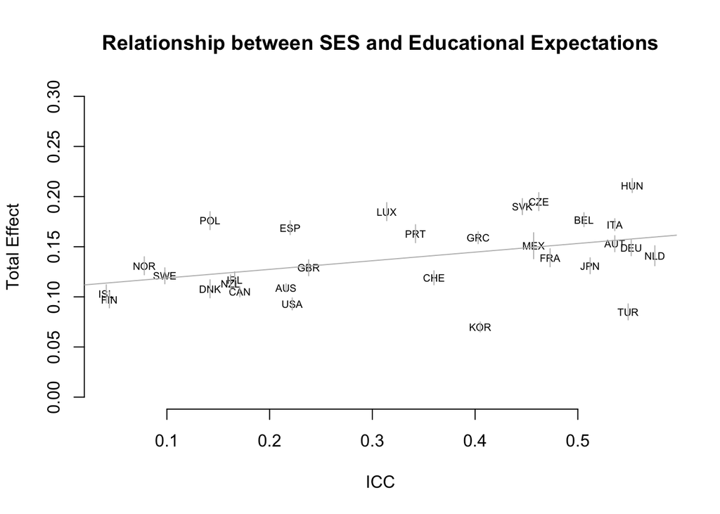

```r
results<-resultsList[[6]]
plot(results[,"ICC"], results[,"total"], ylab="Total Effect", xlab="ICC", ylim=c(0,.3),pch = '', main="Relationship between SES and Educational Expectations", bty = "n")
text(results[,"ICC"],results[,"total"],results[,"CNT"], cex=.6)
abline(lm(results[,"total"]~results[,"ICC"]), col="grey")
arrows(x0 = results[,"ICC"], y0 = results[,"total"]-results[,"totalse"],
       x1 = results[,"ICC"], y1 = results[,"total"]+results[,"totalse"], length=0, col="grey")
```

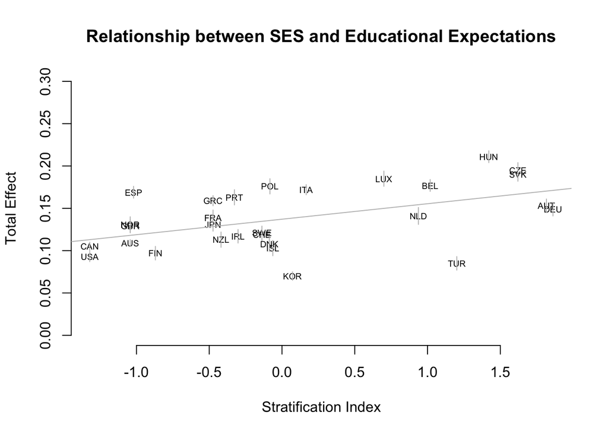

```r
# dev.off()
# devSVG("revisionToAERJ/R3/strat_total.svg")
plot(results[,"strat"], results[,"total"], ylab="Total Effect", xlab="Stratification Index", ylim=c(0,.3),pch = '', main="Relationship between SES and Educational Expectations", bty = "n")
text(results[,"strat"],results[,"total"],results[,"CNT"], cex=.6)
abline(lm(results[,"total"]~results[,"strat"]), col="grey")
arrows(x0 = results[,"strat"], y0 = results[,"total"]-results[,"totalse"],
       x1 = results[,"strat"], y1 = results[,"total"]+results[,"totalse"], length=0, col="grey")
```

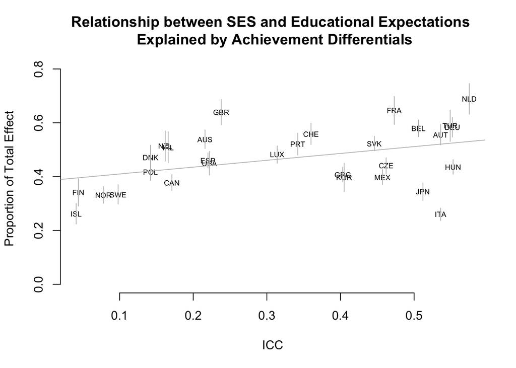

```r
# dev.off()
#Indirect Effect
# devSVG("revisionToAERJ/R3/ICC_ind.svg")
plot(results[,"ICC"], results[,"prop"], ylab="Proportion of Total Effect ", xlab="ICC", ylim=c(0,.8), pch = '',
     main="Relationship between SES and Educational Expectations \n Explained by Achievement Differentials", bty = "n")
text(results[,"ICC"],results[,"prop"],results[,"CNT"], cex=.6)
abline(lm(results[,"prop"]~results[,"ICC"]), col="grey")
arrows(x0 = results[,"ICC"], y0 = results[,"prop"]-results[,"propse"],
       x1 = results[,"ICC"], y1 = results[,"prop"]+results[,"propse"], length=0, col="grey")
```

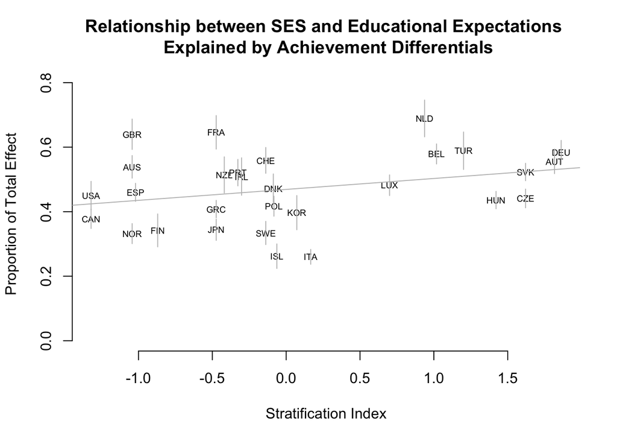

```r
# dev.off()
# devSVG("revisionToAERJ/R3/strat_ind.svg")
plot(results[,"strat"], results[,"prop"], ylab="Proportion of Total Effect ", xlab="Stratification Index", ylim=c(0,.8), pch = '', bty = "n",
     main="Relationship between SES and Educational Expectations \n Explained by Achievement Differentials")
text(results[,"strat"],results[,"prop"],results[,"CNT"], cex=.6)
abline(lm(results[,"prop"]~results[,"strat"]), col="grey")
arrows(x0 = results[,"strat"], y0 = results[,"prop"]-results[,"propse"],
       x1 = results[,"strat"], y1 = results[,"prop"]+results[,"propse"], length=0, col="grey")
```

```r
# dev.off()
```